# Task1

Author

Yuliia Lysaniuk

Published

July 10, 2026

Theme: My Cat Busya

### 1.1. Atomic Types

Create the following variables related to your chosen object:

- **4 numeric** values (e.g., population, temperature, size, rating)
- **3 integer** values (e.g., number of moons, buildings, inhabitants)
- **2 logical** values (e.g., `has_water`, `is_inhabited`)
- **3 character** values (e.g., `name`, `region`, `category`)

**Tip:** Think of these variables as *attributes* of your object.  
Use `print()` or `cat()` to describe them in one sentence.

```r
# Numeric variables
weight <- 4.3            # in kilograms
age <- 3.5               # in years
sleep_hours <- 16.8      # average hours per day
jump_height <- 1.2       # in meters

# Integer variables
num_toys <- 7
num_meals <- 3
num_vet_visits <- 2

# Logical variables
is_lazy <- TRUE
likes_water <- FALSE

# Character variables
name <- "Busya"
breed <- "Scottish Fold"
favorite_food <- "chicken treats"
```

### 1.2. Vectors

Create three different vectors:

1. **Numeric vector** combining all your numeric and integer variables.  
   *(Use `c()`.)*
2. **Sequence vector** from any number between 10–50 to 100, Choose step between 2 and 10.  
   *(Use `seq()` or `:`.)*
3. **Logical vector** of length 10 with random `TRUE`/`FALSE` values using `sample()`.

```r
# 1. Numeric vector (combine numeric + integer)
numeric_vector <- c(weight, age, sleep_hours, jump_height,
                    num_toys, num_meals, num_vet_visits)
print(numeric_vector)
```

```
[1]  4.3  3.5 16.8  1.2  7.0  3.0  2.0
```

```r
# 2. Sequence vector (from 10 to 100, step 10)
sequence_vector <- seq(10, 100, by = 10)
print(sequence_vector)
```

```
 [1]  10  20  30  40  50  60  70  80  90 100
```

```r
# 3. Logical vector (10 random TRUE/FALSE)
logical_vector <- sample(c(TRUE, FALSE), 10, replace = TRUE)
print(logical_vector)
```

```
 [1]  TRUE  TRUE  TRUE  TRUE  TRUE  TRUE  TRUE FALSE  TRUE  TRUE
```

### 1.3. Matrix

Create a **3×3 matrix** with random numbers between **-50 and 50**  
(using `sample()` or `runif()`), and name its **rows and columns** according to your theme.

Then calculate row and column averages using `rowMeans()` and `colMeans()`.

```r
# Create 3x3 matrix with random numbers between -50 and 50
busya_matrix <- matrix(sample(-50:50, 9), nrow = 3, ncol = 3)

# Name rows and columns (related to Busya’s life)
rownames(busya_matrix) <- c("Morning", "Afternoon", "Evening")
colnames(busya_matrix) <- c("Playtime", "NapTime", "EnergyLevel")

print(busya_matrix)
```

```
          Playtime NapTime EnergyLevel
Morning        -45      29         -33
Afternoon      -50     -12          42
Evening         -5       8          21
```

```r
# Row and column means
row_means <- rowMeans(busya_matrix)
col_means <- colMeans(busya_matrix)

cat("\nAverage by rows (daily periods):\n")
```

```
Average by rows (daily periods):
```

```r
print(row_means)
```

```
   Morning  Afternoon    Evening
-16.333333  -6.666667   8.000000
```

```r
cat("\nAverage by columns (activities):\n")
```

```
Average by columns (activities):
```

```r
print(col_means)
```

```
   Playtime     NapTime EnergyLevel
 -33.333333    8.333333   10.000000
```

### 1.4. List

Create a **list** that combines all your previous objects:  
atomic variables, vectors, and matrix. Add one extra element — a short **description** of your universe as a string.

```r
busya_list <- list(
  numerics = numeric_vector,
  sequence = sequence_vector,
  logicals = logical_vector,
  matrix = busya_matrix,
  description = "Busya is a playful Scottish Fold cat who loves naps, chicken treats, and observing birds from the window."
)
print(busya_list)
```

```
$numerics
[1]  4.3  3.5 16.8  1.2  7.0  3.0  2.0

$sequence
 [1]  10  20  30  40  50  60  70  80  90 100

$logicals
 [1]  TRUE  TRUE  TRUE  TRUE  TRUE  TRUE  TRUE FALSE  TRUE  TRUE

$matrix
          Playtime NapTime EnergyLevel
Morning        -45      29         -33
Afternoon      -50     -12          42
Evening         -5       8          21

$description
[1] "Busya is a playful Scottish Fold cat who loves naps, chicken treats, and observing birds from the window."
```

### 1.5. Factor

Create a **factor variable** representing categories within your universe, e.g.:

- `"low"`, `"medium"`, `"high"`
- `"infant"`, `"child"`, `"adult"`
- `"poor"`, `"average"`, `"rich"`

Make sure you have **at least 5 observations** total.  
Then use `table()` to show how many objects fall into each category.

```r
# Factor of Busya’s mood levels during the day
mood_levels <- factor(
  c("happy", "sleepy", "playful", "sleepy", "happy", "grumpy"),
  levels = c("grumpy", "sleepy", "playful", "happy")
)
print(mood_levels)
```

```
[1] happy   sleepy  playful sleepy  happy   grumpy
Levels: grumpy sleepy playful happy
```

```r
# Frequency table
cat("\nBusya’s mood frequency:\n")
```

```
Busya’s mood frequency:
```

```r
print(table(mood_levels))
```

```
mood_levels
 grumpy  sleepy playful   happy
      1       2       1       2
```

### 1.6. Data Frame

Create a **data frame** related to your object that includes:

1. **5–8 observations** (rows)
2. **At least 3 columns** of different data types  
   (e.g., name, numeric value, logical flag, category)

Then:

- Rename the columns using `names()` or `colnames()`.
- Display its structure with `str()` and its summary with `summary()`.
- Add a new column derived from the others (for example, a ratio or condition).

```r
# Create a data frame about Busya’s daily routine
busya_day <- data.frame(
  Activity = c("Eating", "Sleeping", "Playing", "Grooming", "Watching birds"),
  Duration_hours = c(0.5, 16, 2, 1, 1.5),
  Enjoyment_level = c("high", "very high", "very high", "medium", "high"),
  Requires_owner = c(TRUE, FALSE, TRUE, FALSE, FALSE)
)

# Rename columns
colnames(busya_day) <- c("Activity", "Duration_h", "Enjoyment", "With_Owner")

# Display structure and summary
str(busya_day)
```

```
'data.frame':   5 obs. of  4 variables:
 $ Activity  : chr  "Eating" "Sleeping" "Playing" "Grooming" ...
 $ Duration_h: num  0.5 16 2 1 1.5
 $ Enjoyment : chr  "high" "very high" "very high" "medium" ...
 $ With_Owner: logi  TRUE FALSE TRUE FALSE FALSE
```

```r
summary(busya_day)
```

```
   Activity           Duration_h    Enjoyment         With_Owner
 Length:5           Min.   : 0.5   Length:5           Mode :logical
 Class :character   1st Qu.: 1.0   Class :character   FALSE:3
 Mode  :character   Median : 1.5   Mode  :character   TRUE :2
                    Mean   : 4.2
                    3rd Qu.: 2.0
                    Max.   :16.0
```

```r
# Add new column – is_long_activity (more than 1 hour)
busya_day$Is_Long <- busya_day$Duration_h > 1

cat("\nUpdated data frame (Busya's daily routine):\n")
```

```
Updated data frame (Busya's daily routine):
```

```r
print(busya_day)
```

```
        Activity Duration_h Enjoyment With_Owner Is_Long
1         Eating        0.5      high       TRUE   FALSE
2       Sleeping       16.0 very high      FALSE    TRUE
3        Playing        2.0 very high       TRUE    TRUE
4       Grooming        1.0    medium      FALSE   FALSE
5 Watching birds        1.5      high      FALSE    TRUE
```

## Task 2: Subsetting & Missing Data in Your Mini-Universe

### 2.1. Querying Vectors

Let’s start with the vectors you created in **Task 1**.

2.1.1. From your **Sequence vector** (the one with all your numbers):

- Select and print the 3rd element.
- Select and print elements 2 through 5.
- Select and print all values that are greater than 20 (or another number that makes sense for your data).

2.1.2. From your **Logical vector**:

- Select and print only the TRUE values. (Hint: `your_vector[your_vector]`).
- Use `which()` to get the indices (positions) of all the `TRUE` values.

```r
# 2.1.1 Sequence vector

cat("3rd element:", sequence_vector[3], "\n")
```

```
3rd element: 30
```

```r
cat("Elements 2-5:", sequence_vector[2:5], "\n")
```

```
Elements 2-5: 20 30 40 50
```

```r
cat("Values > 20:", sequence_vector[sequence_vector > 20], "\n")
```

```
Values > 20: 30 40 50 60 70 80 90 100
```

```r
# 2.1.2 Logical vector

true_values <- logical_vector[logical_vector]
cat("TRUE values:", true_values, "\n")
```

```
TRUE values: TRUE TRUE TRUE TRUE TRUE TRUE TRUE TRUE TRUE
```

```r
true_indices <- which(logical_vector)
cat("Indices of TRUE values:", true_indices, "\n")
```

```
Indices of TRUE values: 1 2 3 4 5 6 7 9 10
```

### 2.2. Querying Your “Universe” List

Use your main list from **Task 1**.

- Access and print the **description** string using the `$` operator
- Access and print your **3x3 matrix** using double brackets `[[ ]]`.
- Access and print the **second element** from your **vector element** within the list. (This will be a “list-within-a-list” access).

```r
cat("Description:", busya_list$description, "\n")
```

```
Description: Busya is a playful Scottish Fold cat who loves naps, chicken treats, and observing birds from the window.
```

```r
cat("Matrix:\n")
```

```
Matrix:
```

```r
print(busya_list[["matrix"]])
```

```
          Playtime NapTime EnergyLevel
Morning        -45      29         -33
Afternoon      -50     -12          42
Evening         -5       8          21
```

```r
cat("Second element of numeric vector in list:", busya_list$numerics[2], "\n")
```

```
Second element of numeric vector in list: 3.5
```

### 2.3. Investigating Your Data Frame

Use the **data frame** you created in **Task 1**.

- Print the **first 3 rows**. (Use `head()`.)
- Print the value from the **4th row, 1st column**.
- Print only the column that contains your logical values (e.g., `is_habitable`) as a vector.

**Logical Subsetting**: Create a new data frame `df_subset` that contains only the rows that meet a specific logical condition.

- Example: `df_subset <- your_df[your_df$population > 1000, ]`

`%in%` **Subsetting**: Create a new data frame `df_subset_2` that selects rows belonging to **two specific categories** from your factor or character column.

- Example: `df_subset_2 <- your_df[your_df$region %in% c("North", "South"), ]`

```r
cat("First 3 rows:\n")
```

```
First 3 rows:
```

```r
print(head(busya_day, 3))
```

```
  Activity Duration_h Enjoyment With_Owner Is_Long
1   Eating        0.5      high       TRUE   FALSE
2 Sleeping       16.0 very high      FALSE    TRUE
3  Playing        2.0 very high       TRUE    TRUE
```

```r
cat("Value at [4,1]:", busya_day[4, 1], "\n")
```

```
Value at [4,1]: Grooming
```

```r
cat("Logical column (With_Owner):\n")
```

```
Logical column (With_Owner):
```

```r
print(busya_day$With_Owner)
```

```
[1]  TRUE FALSE  TRUE FALSE FALSE
```

```r
# Logical subsetting

df_subset <- busya_day[busya_day$Duration_h > 1, ]
cat("Subset of long activities (>1h):\n")
```

```
Subset of long activities (>1h):
```

```r
print(df_subset)
```

```
        Activity Duration_h Enjoyment With_Owner Is_Long
2       Sleeping       16.0 very high      FALSE    TRUE
3        Playing        2.0 very high       TRUE    TRUE
5 Watching birds        1.5      high      FALSE    TRUE
```

```r
# %in% subsetting

df_subset_2 <- busya_day[busya_day$Enjoyment %in% c("high", "very high"), ]
cat("Subset of activities with high enjoyment:\n")
```

```
Subset of activities with high enjoyment:
```

```r
print(df_subset_2)
```

```
        Activity Duration_h Enjoyment With_Owner Is_Long
1         Eating        0.5      high       TRUE   FALSE
2       Sleeping       16.0 very high      FALSE    TRUE
3        Playing        2.0 very high       TRUE    TRUE
5 Watching birds        1.5      high      FALSE    TRUE
```

### 2.4. Handling “Corrupted” Data (`NA`)

Create a copy of your original data frame (e.g., `df_corrupted <- your_df`).

**Introduce 3 `NA`s** into your df_corrupted at specific locations.

- Example: `df_corrupted[2, 3] <- NA`

**Find `NAs`**:

- Use `sum(is.na(df_corrupted)`) to find the **total number** of missing values.
- Use `colSums(is.na(df_corrupted))` to see how many `NA`s are in **each column**.

**Calculate with `NA`s**:

- Calculate the `mean()` of the numeric column where you added an `NA`.

**Filter `NA`s**:

- Use `na.omit(df_corrupted)` to create a new, “clean” data frame that contains only the complete rows.

```r
df_corrupted <- busya_day
df_corrupted[2, "Duration_h"] <- NA
df_corrupted[5, "Enjoyment"] <- NA
df_corrupted[3, "With_Owner"] <- NA

cat("Corrupted Data Frame with NAs:\n")
```

```
Corrupted Data Frame with NAs:
```

```r
print(df_corrupted)
```

```
        Activity Duration_h Enjoyment With_Owner Is_Long
1         Eating        0.5      high       TRUE   FALSE
2       Sleeping         NA very high      FALSE    TRUE
3        Playing        2.0 very high         NA    TRUE
4       Grooming        1.0    medium      FALSE   FALSE
5 Watching birds        1.5      <NA>      FALSE    TRUE
```

```r
total_na <- sum(is.na(df_corrupted))
cat("Total NAs:", total_na, "\n")
```

```
Total NAs: 3
```

```r
cat("NAs per column:\n")
```

```
NAs per column:
```

```r
print(colSums(is.na(df_corrupted)))
```

```
  Activity Duration_h  Enjoyment With_Owner    Is_Long
         0          1          1          1          0
```

```r
mean_duration <- mean(df_corrupted$Duration_h, na.rm = TRUE)
cat("Mean Duration_h (ignoring NA):", mean_duration, "\n")
```

```
Mean Duration_h (ignoring NA): 1.25
```

```r
df_clean <- na.omit(df_corrupted)
cat("Cleaned data frame (no NAs):\n")
```

```
Cleaned data frame (no NAs):
```

```r
print(df_clean)
```

```
  Activity Duration_h Enjoyment With_Owner Is_Long
1   Eating        0.5      high       TRUE   FALSE
4 Grooming        1.0    medium      FALSE   FALSE
```

### 2.5. Bonus Challenge: `which()`

Use `which.max()` or `which.min()` to find the **row number** (index) of the observation with the highest or lowest value in one of your numeric columns.

Use that index to print the row with that observation.

- Example: `highest_pop_index <- which.max(your_df$population)`
- Example: `your_df[highest_pop_index, ]`

```r
highest_duration_index <- which.max(busya_day$Duration_h)
cat("Row with highest Duration_h:\n")
```

```
Row with highest Duration_h:
```

```r
print(busya_day[highest_duration_index, ])
```

```
  Activity Duration_h Enjoyment With_Owner Is_Long
2 Sleeping         16 very high      FALSE    TRUE
```

## Task 3: Expanding Your Universe

### 3.1. The Quest: Find Your Data

### 3.2. The Import: Load Your Data

```r
# Load libraries
library(dplyr)
library(readr)

# Import the dataset
world_cities <- read_csv("worldcities.csv")
# First inspection
glimpse(world_cities)
```

```
Rows: 48,059
Columns: 11
$ city       <chr> "Tokyo", "Jakarta", "Delhi", "Guangzhou", "Mumbai", "Manila…
$ city_ascii <chr> "Tokyo", "Jakarta", "Delhi", "Guangzhou", "Mumbai", "Manila…
$ lat        <dbl> 35.6870, -6.1750, 28.6100, 23.1300, 19.0761, 14.5958, 31.22…
$ lng        <dbl> 139.7495, 106.8275, 77.2300, 113.2600, 72.8775, 120.9772, 1…
$ country    <chr> "Japan", "Indonesia", "India", "China", "India", "Philippin…
$ iso2       <chr> "JP", "ID", "IN", "CN", "IN", "PH", "CN", "BR", "KR", "MX",…
$ iso3       <chr> "JPN", "IDN", "IND", "CHN", "IND", "PHL", "CHN", "BRA", "KO…
$ admin_name <chr> "Tōkyō", "Jakarta", "Delhi", "Guangdong", "Mahārāshtra", "M…
$ capital    <chr> "primary", "primary", "admin", "admin", "admin", "primary",…
$ population <dbl> 37785000, 33756000, 32226000, 26940000, 24973000, 24922000,…
$ id         <dbl> 1392685764, 1360771077, 1356872604, 1156237133, 1356226629,…
```

```r
head(world_cities)
```

```
# A tibble: 6 × 11
  city  city_ascii   lat   lng country iso2  iso3  admin_name capital population
  <chr> <chr>      <dbl> <dbl> <chr>   <chr> <chr> <chr>      <chr>        <dbl>
1 Tokyo Tokyo      35.7  140.  Japan   JP    JPN   Tōkyō      primary   37785000
2 Jaka… Jakarta    -6.18 107.  Indone… ID    IDN   Jakarta    primary   33756000
3 Delhi Delhi      28.6   77.2 India   IN    IND   Delhi      admin     32226000
4 Guan… Guangzhou  23.1  113.  China   CN    CHN   Guangdong  admin     26940000
5 Mumb… Mumbai     19.1   72.9 India   IN    IND   Mahārāsht… admin     24973000
6 Mani… Manila     14.6  121.  Philip… PH    PHL   Manila     primary   24922000
# ℹ 1 more variable: id <dbl>
```

```r
summary(world_cities)
```

```
     city            city_ascii             lat              lng
 Length:48059       Length:48059       Min.   :-54.93   Min.   :-179.60
 Class :character   Class :character   1st Qu.: 12.19   1st Qu.: -44.16
 Mode  :character   Mode  :character   Median : 30.93   Median :  14.48
                                       Mean   : 25.39   Mean   :  16.25
                                       3rd Qu.: 42.62   3rd Qu.:  77.08
                                       Max.   : 81.72   Max.   : 179.37

   country              iso2               iso3            admin_name
 Length:48059       Length:48059       Length:48059       Length:48059
 Class :character   Class :character   Class :character   Class :character
 Mode  :character   Mode  :character   Mode  :character   Mode  :character




   capital            population             id
 Length:48059       Min.   :       0   Min.   :1.004e+09
 Class :character   1st Qu.:   12191   1st Qu.:1.251e+09
 Mode  :character   Median :   20914   Median :1.380e+09
                    Mean   :  107857   Mean   :1.447e+09
                    3rd Qu.:   46808   3rd Qu.:1.704e+09
                    Max.   :37785000   Max.   :1.935e+09
                    NA's   :251
```

### 3.3. The Interrogation: Explore with `dplyr`

**5 Questions

**Question 1:** Which 10 cities have the largest population?

```r
world_cities %>%
  select(city, country, population) %>%
  arrange(desc(population)) %>%
  head(10)
```

```
# A tibble: 10 × 3
   city        country      population
   <chr>       <chr>             <dbl>
 1 Tokyo       Japan          37785000
 2 Jakarta     Indonesia      33756000
 3 Delhi       India          32226000
 4 Guangzhou   China          26940000
 5 Mumbai      India          24973000
 6 Manila      Philippines    24922000
 7 Shanghai    China          24073000
 8 São Paulo   Brazil         23086000
 9 Seoul       Korea, South   23016000
10 Mexico City Mexico         21804000
```

**Question 2:** What is the average population by country? (top 10 by population)

```r
world_cities %>%
  group_by(country) %>%
  summarise(avg_population = mean(population, na.rm = TRUE)) %>%
  arrange(desc(avg_population)) %>%
  head(10)
```

```
# A tibble: 10 × 2
   country              avg_population
   <chr>                         <dbl>
 1 Singapore                  5983000
 2 China                       793959.
 3 Kuwait                      734392.
 4 United Arab Emirates        643447.
 5 Korea, South                597435.
 6 Macau                       568700
 7 Nigeria                     559192.
 8 Hong Kong                   532750.
 9 Sudan                       435386.
10 Bangladesh                  387878.
```

**Question 3:** How many cities exist for each capital type (primary, admin, minor, NA)?

```r
world_cities %>%
  group_by(capital) %>%
  summarise(count = n())
```

```
# A tibble: 4 × 2
  capital count
  <chr>   <int>
1 admin    3639
2 minor   11248
3 primary   251
4 <NA>    32921
```

**Question 4:** Create a new variable population_millions and show the top 10 cities.

```r
world_cities %>%
  mutate(population_millions = population / 1e6) %>%
  select(city, country, population_millions) %>%
  arrange(desc(population_millions)) %>%
  head(10)
```

```
# A tibble: 10 × 3
   city        country      population_millions
   <chr>       <chr>                      <dbl>
 1 Tokyo       Japan                       37.8
 2 Jakarta     Indonesia                   33.8
 3 Delhi       India                       32.2
 4 Guangzhou   China                       26.9
 5 Mumbai      India                       25.0
 6 Manila      Philippines                 24.9
 7 Shanghai    China                       24.1
 8 São Paulo   Brazil                      23.1
 9 Seoul       Korea, South                23.0
10 Mexico City Mexico                      21.8
```

**Question 5:** Filter all cities with population > 5 million and sort them from largest to smallest

```r
world_cities %>%
  filter(population > 5e6) %>%
  select(city, country, population) %>%
  arrange(desc(population))
```

```
# A tibble: 129 × 3
   city        country      population
   <chr>       <chr>             <dbl>
 1 Tokyo       Japan          37785000
 2 Jakarta     Indonesia      33756000
 3 Delhi       India          32226000
 4 Guangzhou   China          26940000
 5 Mumbai      India          24973000
 6 Manila      Philippines    24922000
 7 Shanghai    China          24073000
 8 São Paulo   Brazil         23086000
 9 Seoul       Korea, South   23016000
10 Mexico City Mexico         21804000
# ℹ 119 more rows
```

## Task 4. Building a “Toolkit” for Your Universe (Functions)

### 4.1. The “Greeting” Function (A Simple Start)

```r
welcome_to_my_universe <- function(your_name) {
  cat("--------------------------------------------\n")
  cat(" Welcome to the World Cities Analysis Toolkit\n")
  cat(" Report prepared by:", your_name, "\n")
  cat("--------------------------------------------\n")
}

welcome_to_my_universe("Yuliia")
```

```
--------------------------------------------
 Welcome to the World Cities Analysis Toolkit
 Report prepared by: Yuliia
--------------------------------------------
```

### 4.2. The “Loading” Function

```r
library(readr)
library(dplyr)
library(ggplot2)

load_and_inspect <- function(file_path) {
  data <- read_csv(file_path)

  cat("--- Data loaded successfully from:", file_path, "---\n\n")

  cat("----- STRUCTURE -----\n")
  print(glimpse(data))

  cat("\n----- FIRST 6 ROWS -----\n")
  print(head(data))

  return(data)
}

# Load data from your folder
world_cities <- load_and_inspect("C:/Users/ylysa/Desktop/pocpodpora/worldcities.csv")
```

```
--- Data loaded successfully from: C:/Users/ylysa/Desktop/pocpodpora/worldcities.csv ---

----- STRUCTURE -----
Rows: 48,059
Columns: 11
$ city       <chr> "Tokyo", "Jakarta", "Delhi", "Guangzhou", "Mumbai", "Manila…
$ city_ascii <chr> "Tokyo", "Jakarta", "Delhi", "Guangzhou", "Mumbai", "Manila…
$ lat        <dbl> 35.6870, -6.1750, 28.6100, 23.1300, 19.0761, 14.5958, 31.22…
$ lng        <dbl> 139.7495, 106.8275, 77.2300, 113.2600, 72.8775, 120.9772, 1…
$ country    <chr> "Japan", "Indonesia", "India", "China", "India", "Philippin…
$ iso2       <chr> "JP", "ID", "IN", "CN", "IN", "PH", "CN", "BR", "KR", "MX",…
$ iso3       <chr> "JPN", "IDN", "IND", "CHN", "IND", "PHL", "CHN", "BRA", "KO…
$ admin_name <chr> "Tōkyō", "Jakarta", "Delhi", "Guangdong", "Mahārāshtra", "M…
$ capital    <chr> "primary", "primary", "admin", "admin", "admin", "primary",…
$ population <dbl> 37785000, 33756000, 32226000, 26940000, 24973000, 24922000,…
$ id         <dbl> 1392685764, 1360771077, 1356872604, 1156237133, 1356226629,…
# A tibble: 48,059 × 11
   city        city_ascii     lat   lng country   iso2  iso3  admin_name capital
   <chr>       <chr>        <dbl> <dbl> <chr>     <chr> <chr> <chr>      <chr>
 1 Tokyo       Tokyo        35.7  140.  Japan     JP    JPN   Tōkyō      primary
 2 Jakarta     Jakarta      -6.18 107.  Indonesia ID    IDN   Jakarta    primary
 3 Delhi       Delhi        28.6   77.2 India     IN    IND   Delhi      admin
 4 Guangzhou   Guangzhou    23.1  113.  China     CN    CHN   Guangdong  admin
 5 Mumbai      Mumbai       19.1   72.9 India     IN    IND   Mahārāsht… admin
 6 Manila      Manila       14.6  121.  Philippi… PH    PHL   Manila     primary
 7 Shanghai    Shanghai     31.2  121.  China     CN    CHN   Shanghai   admin
 8 São Paulo   Sao Paulo   -23.6  -46.6 Brazil    BR    BRA   São Paulo  admin
 9 Seoul       Seoul        37.6  127.  Korea, S… KR    KOR   Seoul      primary
10 Mexico City Mexico City  19.4  -99.1 Mexico    MX    MEX   Ciudad de… primary
# ℹ 48,049 more rows
# ℹ 2 more variables: population <dbl>, id <dbl>

----- FIRST 6 ROWS -----
# A tibble: 6 × 11
  city  city_ascii   lat   lng country iso2  iso3  admin_name capital population
  <chr> <chr>      <dbl> <dbl> <chr>   <chr> <chr> <chr>      <chr>        <dbl>
1 Tokyo Tokyo      35.7  140.  Japan   JP    JPN   Tōkyō      primary   37785000
2 Jaka… Jakarta    -6.18 107.  Indone… ID    IDN   Jakarta    primary   33756000
3 Delhi Delhi      28.6   77.2 India   IN    IND   Delhi      admin     32226000
4 Guan… Guangzhou  23.1  113.  China   CN    CHN   Guangdong  admin     26940000
5 Mumb… Mumbai     19.1   72.9 India   IN    IND   Mahārāsht… admin     24973000
6 Mani… Manila     14.6  121.  Philip… PH    PHL   Manila     primary   24922000
# ℹ 1 more variable: id <dbl>
```

### 4.3. The “Query” Function

```r
filter_cities_by_population <- function(data, pop_threshold) {
  result <- data %>%
    filter(population > pop_threshold) %>%
    select(city, country, population) %>%
    arrange(desc(population))

  return(result)
}

big_cities <- filter_cities_by_population(world_cities, 5000000)
print(big_cities)
```

```
# A tibble: 129 × 3
   city        country      population
   <chr>       <chr>             <dbl>
 1 Tokyo       Japan          37785000
 2 Jakarta     Indonesia      33756000
 3 Delhi       India          32226000
 4 Guangzhou   China          26940000
 5 Mumbai      India          24973000
 6 Manila      Philippines    24922000
 7 Shanghai    China          24073000
 8 São Paulo   Brazil         23086000
 9 Seoul       Korea, South   23016000
10 Mexico City Mexico         21804000
# ℹ 119 more rows
```

### 4.4. The “Reporting” Function

```r
generate_report <- function(data, country_name) {

  country_data <- data %>%
    filter(country == country_name)

  if (nrow(country_data) == 0) {
    cat("No cities found for:", country_name, "\n")
    return(NULL)
  }

  city_count <- nrow(country_data)
  max_pop <- max(country_data$population, na.rm = TRUE)
  avg_pop <- mean(country_data$population, na.rm = TRUE)
  min_pop <- min(country_data$population, na.rm = TRUE)

  cat("----------- REPORT FOR:", country_name, "-----------\n")
  cat("Number of cities:", city_count, "\n")
  cat("Maximum population:", max_pop, "\n")
  cat("Average population:", round(avg_pop, 2), "\n")
  cat("Minimum population:", min_pop, "\n")
  cat("-----------------------------------------------\n\n")
}

generate_report(world_cities, "Ukraine")
```

```
----------- REPORT FOR: Ukraine -----------
Number of cities: 462
Maximum population: 2952301
Average population: 59406.9
Minimum population: 8506
-----------------------------------------------
```

```r
generate_report(world_cities, "Slovakia")
```

```
----------- REPORT FOR: Slovakia -----------
Number of cities: 83
Maximum population: 475503
Average population: 32408.29
Minimum population: 8526
-----------------------------------------------
```

## Task 5. Visualising Your Universe (Base R & ggplot2)

### 5.1. The Quick Sketch (Base R Histogram)

```r
library(dplyr)
library(readr)
library(ggplot2)

# Load again (optional)
world_cities <- read_csv("C:/Users/ylysa/Desktop/pocpodpora/worldcities.csv")
```

Sometimes you need a quick look at the distribution of your data without loading heavy packages.

1. Choose one **numeric variable** from your dataset (e.g., `price`, `temperature`, `speed`).
2. Use the `hist()` function from base R.
3. Customise the `main` title, `xlab`, and the bar `col` (colour).

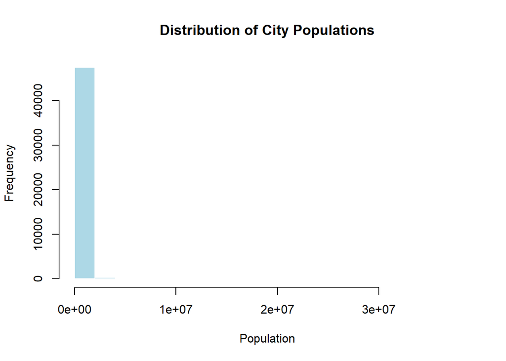

```r
hist(world_cities$population,
     main = "Distribution of City Populations",
     xlab = "Population",
     col = "lightblue",
     border = "white")
```

### 5.2. The Relationship Map (ggplot2 Scatter Plot)

Now, let’s look for patterns using the industry-standard package, **ggplot2**.

1. Choose **two numeric variables** to see if they are correlated.
2. Create a scatter plot using `geom_point()`.
3. Add `geom_smooth()` to add a relationship between variables to the plot.
4. Add `labs()` to rename your axes and title.

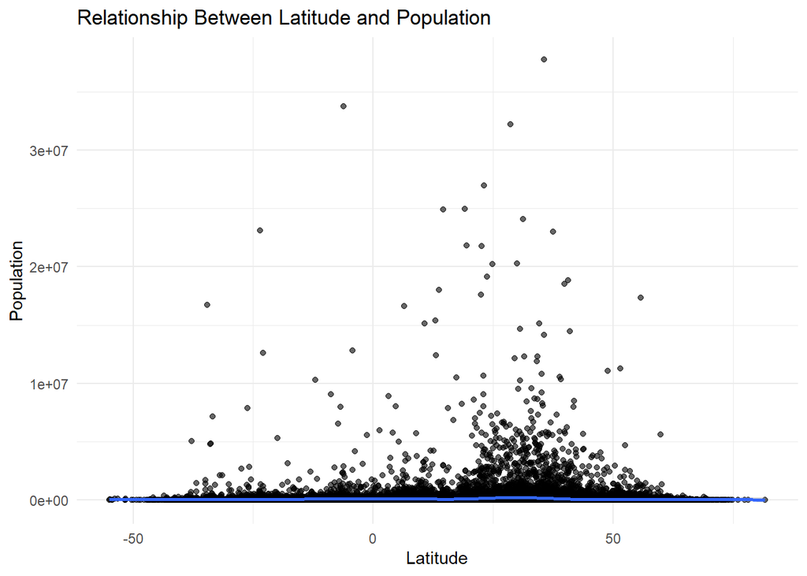

```r
ggplot(world_cities, aes(x = lat, y = population)) +
  geom_point(alpha = 0.6) +
  geom_smooth() +
  labs(title = "Relationship Between Latitude and Population",
       x = "Latitude",
       y = "Population") +
  theme_minimal()
```

### 5.3. The Comparison (ggplot2 Boxplot)

3. The Comparison (ggplot2 Boxplot)

Boxplots are excellent for comparing groups. Let’s see how different categories in your universe perform.

1. Choose a **categorical (or logical) variable** for the X-axis (e.g., city, planet_type, species).
2. Choose a **numeric variable** for the Y-axis (e.g., price, gravity, lifespan).
3. Create a plot using `geom_boxplot()`.
4. **Bonus:** Use `fill` to colour the boxes by the same category.

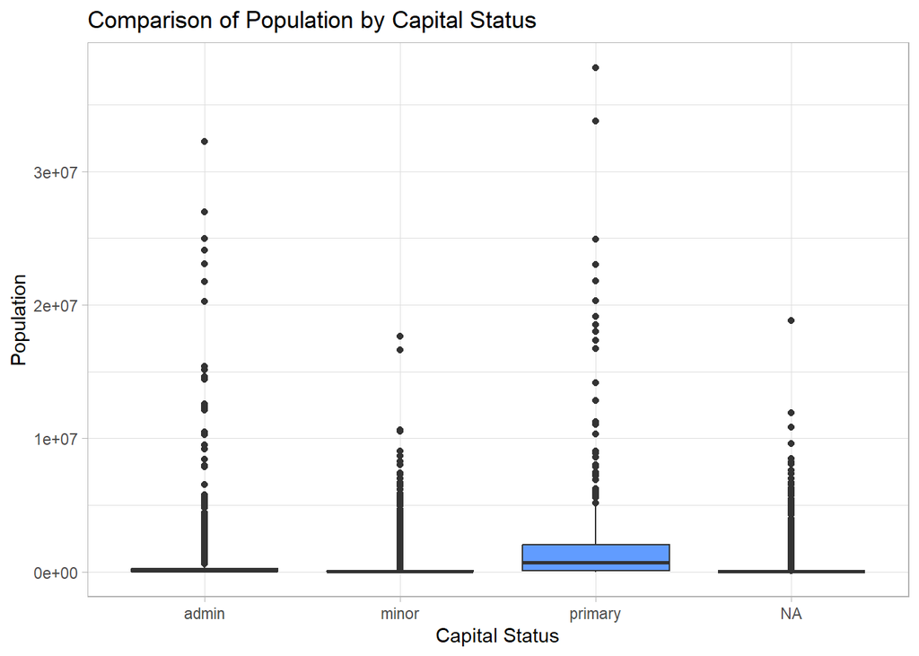

```r
ggplot(world_cities, aes(x = capital, y = population, fill = capital)) +
  geom_boxplot() +
  labs(title = "Comparison of Population by Capital Status",
       x = "Capital Status",
       y = "Population") +
  theme_light() +
  theme(legend.position = "none")
```

### 5.4. The “Deep Dive” (Faceting or Custom)

The most powerful feature of `ggplot2` is faceting—creating small multiples of the same plot for different groups.

1. Create a plot (histogram, bar plot, or scatter plot).
2. Use `facet_wrap(~ your_category_variable)` to split the plot into a separate panel for each group in your data.
3. This is incredibly useful for comparing distinct groups (e.g., separate charts for each City or Year).

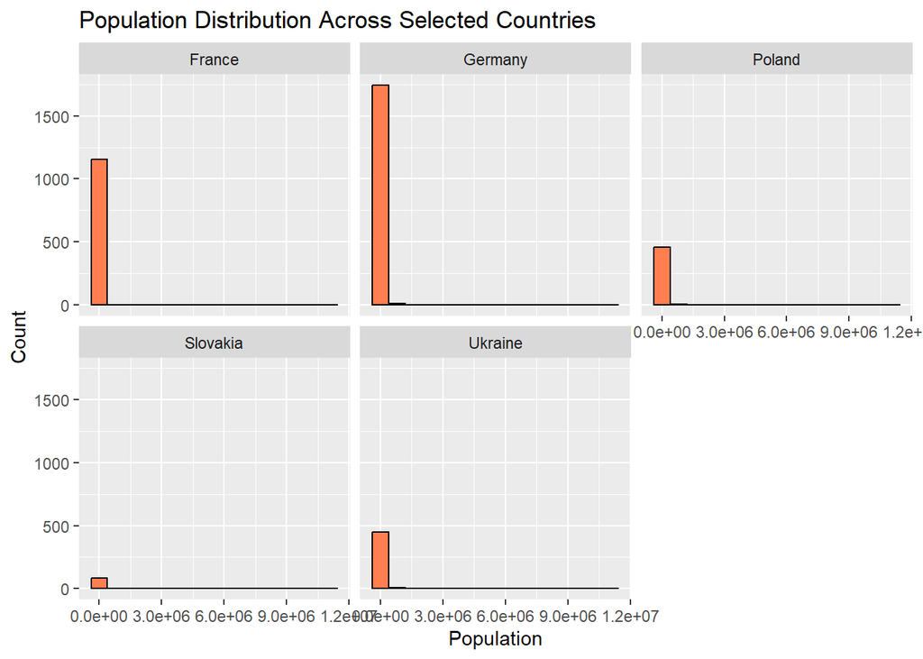

```r
world_cities_small <- world_cities |>
  filter(country %in% c("Slovakia", "Ukraine", "Poland", "Germany", "France"))

ggplot(world_cities_small, aes(x = population)) +
  geom_histogram(bins = 15, fill = "coral", color = "black") +
  facet_wrap(~ country) +
  labs(title = "Population Distribution Across Selected Countries",
       x = "Population",
       y = "Count")
```

### 5.5. Final Step: Exporting (Saving Your Work)

A plot is useless if you can’t put it in a report.

1. Choose your favourite plot from the exercises above.
2. Run the code to display it in R.
3. Immediately run the following command to save it to your project folder:

```r
final_plot <- ggplot(world_cities, aes(x = lat, y = population)) +
  geom_point()

ggsave("C:/Users/ylysa/Desktop/pocpodpora/my_universe_plot.png",
       plot = final_plot,
       width = 8,
       height = 6)
```